# Visualizations of the American Food System

Julia Whiting

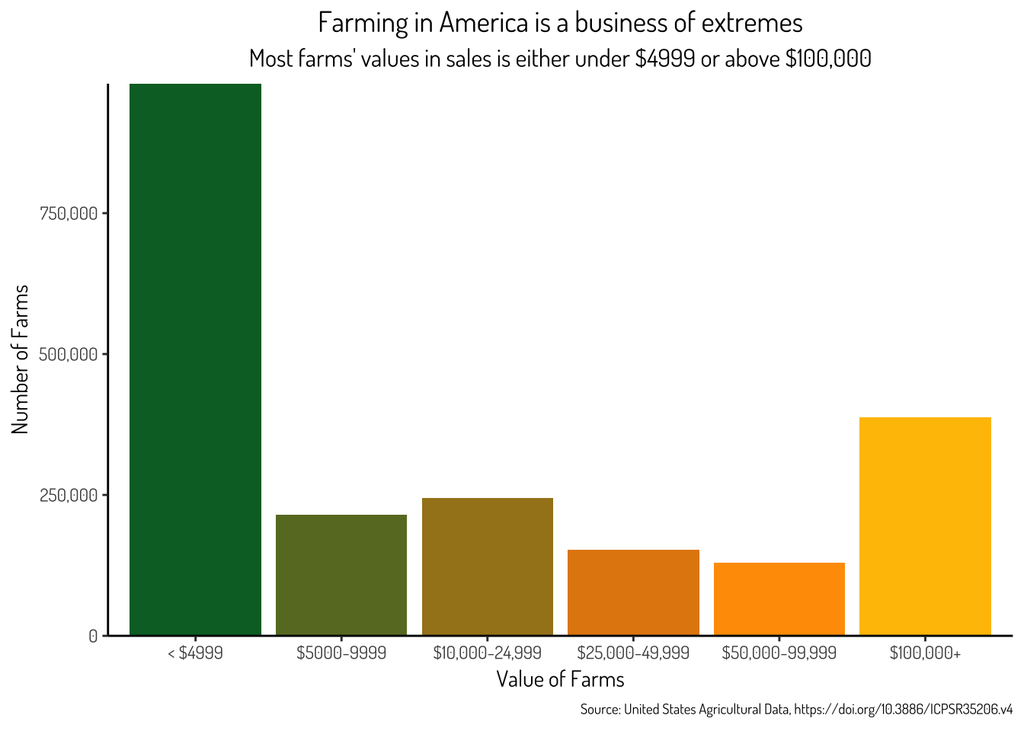

Taking annual sales to stand in for farm value, an interesting pattern emerges. Most farms in the United States earn less than $5000. The next most are the top earners, taking in over $100,000 in sales. It would appear that farming as a profession with a reasonable income no longer the norm.

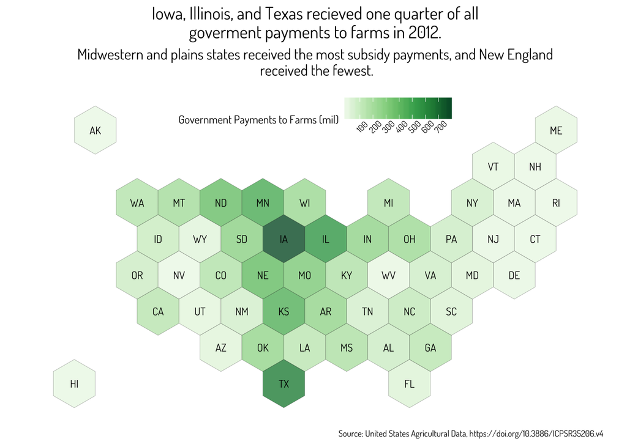

Many farms receive payments from the government through subsidies. Most subsidies fund commodity crops, such as corn, wheat, and cotton. Subsidies are concentrated in states that produce these commodities, mostly in the Midwest and Plains states. Because of the relationship between crops and subsidies, the state that receives the most government payments is not the state with the most farms.

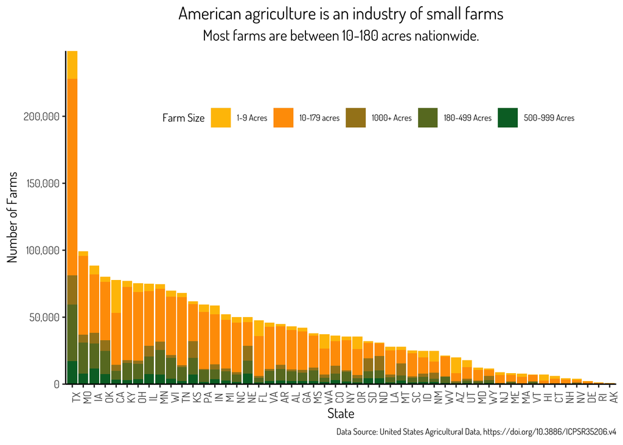

Most farms in the US are relatively small. Many food experts will tell you that farm sizes in the US are growing. Yet most farms are still under .25 square miles (180 acres). Texas has approximately double the number of farms than the next state.

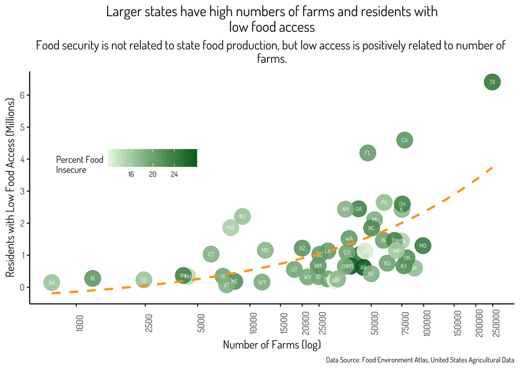

There is a positive relationship between number of farms in a state and number of residents with low food access. Low access to food is defined as living more than one mile away from a groccery store in urban areas, and more than 10 miles away from a groccery store in rural areas. Food insecurity is defined as being unable to provide adequate food for one or more household members at some time during the year. While food access is related to number of farms, food insecurity is not related to access to food. There may be food produced in a state, but the ability of residents to buy that food is another matter entirely.